# DSC1107 Formative Assessment 1

DESQUITADO, Yuichi P.

2024-02-16

Load the needed packages.

```r
library(tidyverse)
library(DescTools)
diamonds
```

```
## # A tibble: 53,940 × 10
##    carat cut       color clarity depth table price     x     y     z
##    <dbl> <ord>     <ord> <ord>   <dbl> <dbl> <int> <dbl> <dbl> <dbl>
##  1  0.23 Ideal     E     SI2      61.5    55   326  3.95  3.98  2.43
##  2  0.21 Premium   E     SI1      59.8    61   326  3.89  3.84  2.31
##  3  0.23 Good      E     VS1      56.9    65   327  4.05  4.07  2.31
##  4  0.29 Premium   I     VS2      62.4    58   334  4.2   4.23  2.63
##  5  0.31 Good      J     SI2      63.3    58   335  4.34  4.35  2.75
##  6  0.24 Very Good J     VVS2     62.8    57   336  3.94  3.96  2.48
##  7  0.24 Very Good I     VVS1     62.3    57   336  3.95  3.98  2.47
##  8  0.26 Very Good H     SI1      61.9    55   337  4.07  4.11  2.53
##  9  0.22 Fair      E     VS2      65.1    61   337  3.87  3.78  2.49
## 10  0.23 Very Good H     VS1      59.4    61   338  4     4.05  2.39
## # ℹ 53,930 more rows
```

# **Lecture 2**

Discrete Variables - We usually use bar charts to visualize discrete variables.

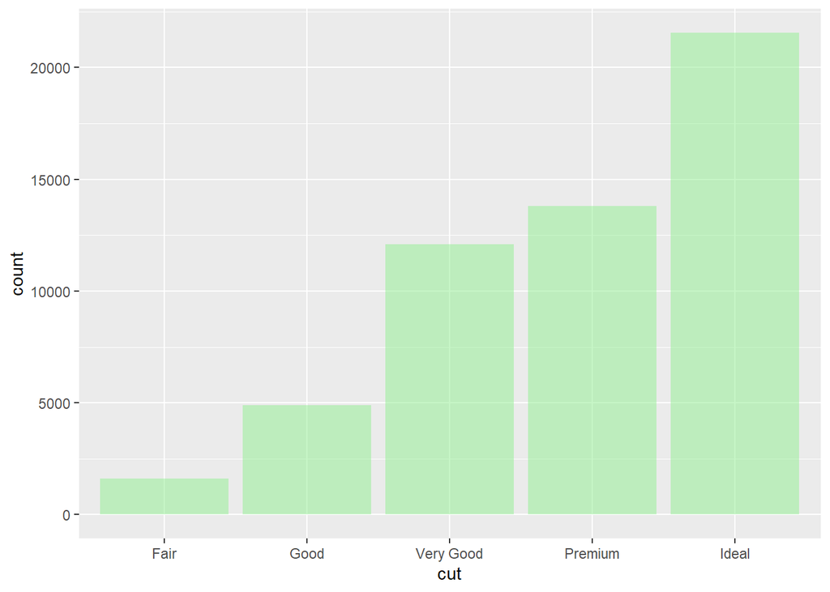

```r
ggplot(data = diamonds) +
  geom_bar(mapping = aes(x = cut),
           fill = "lightgreen",
           alpha = 0.5)
```

INTERPRETATION: This plot implies that 20000 diamonds have ideal cut, which is the greatest count compared to others, such as Premium, Very good, Good, and Fair.

Continuous Variables - We usually use histograms for continuous variable visualization.

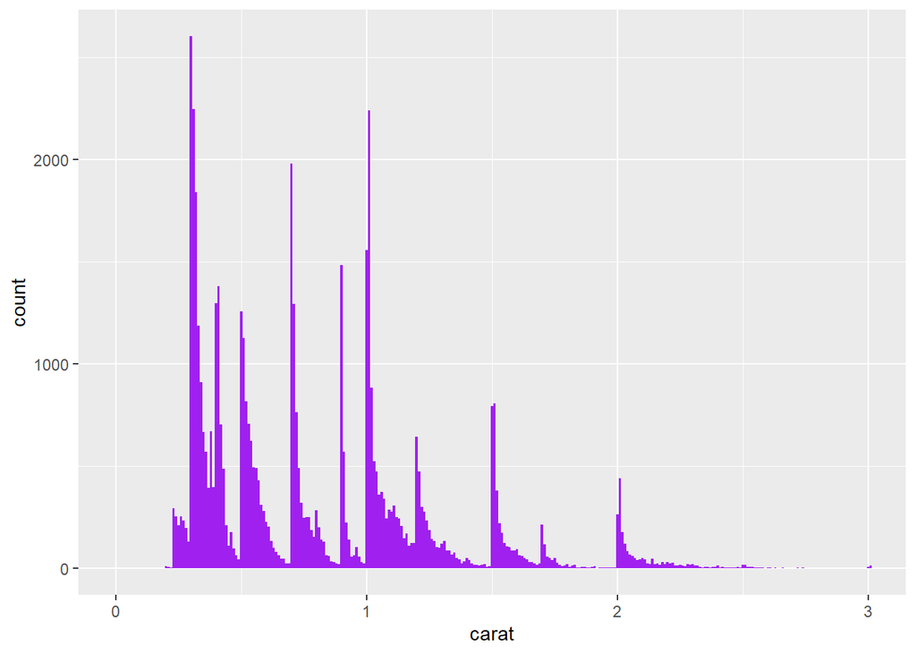

```r
ggplot(data = diamonds) +
  geom_histogram(
    mapping = aes(x = carat),
    binwidth = 0.01,
    fill = "purple") +
  coord_cartesian(xlim = c(0, 3))
```

```r
Mode(diamonds$carat)
```

```
## [1] 0.3
## attr(,"freq")
## [1] 2604
```

INTERPRETATION: This plot shows that a value between 0.25 and 0.50 has the highest count in carat. If we check the mode of the dataset diamonds$carat, it is “0.3” with 2604 entries.

Discrete vs. Discrete - We use count plots to visualize covariation between two discrete variables.

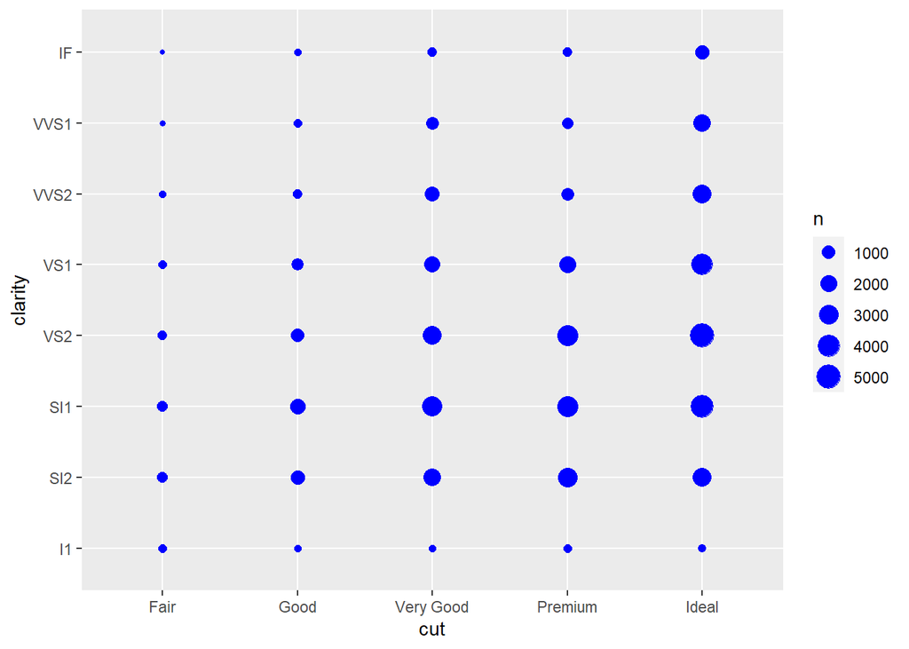

```r
ggplot(data = diamonds) +
  geom_count(mapping = aes(x = cut,
                           y = clarity),
             color = "blue")
```

INTERPRETATION: According to the plot, the most abundant diamonds with specific cut and clarity are ideal-VS2, which has around 5000 count.

Continuous vs. Continuous (Many to One) - Scatter plot is used for comparing covariations of continuous variables (many to one).

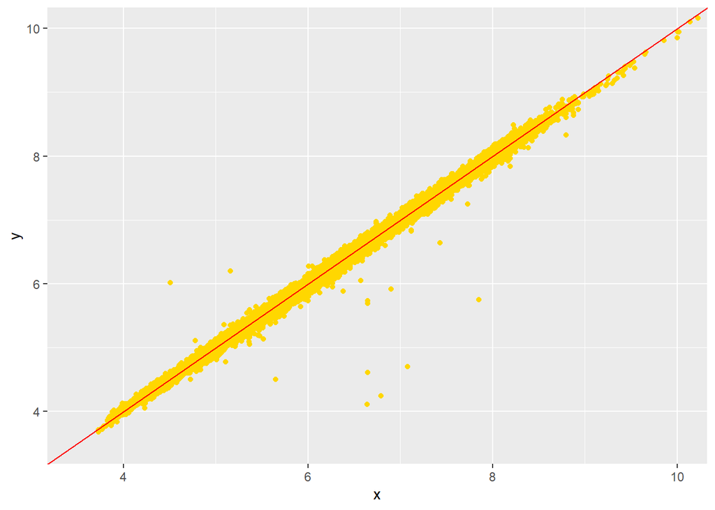

```r
ggplot(data = diamonds) +
  geom_point(mapping = aes(x = x,
                           y = y),
             color = "gold") +
  geom_abline(slope = 1,
              intercept = 0,
              color = "red") +
  coord_cartesian(xlim = c(3.5, 10),
                  ylim = c(3.5, 10))
```

Continuous vs. Continuous (One to One) - Line plot is used for comparing covariations of continuous variables (one to one).

```r
avgPriceByCarat <- diamonds %>%
  mutate(carat = round(carat, 1)) %>%
  group_by(carat) %>%
  summarise(avg_price = mean(price))
avgPriceByCarat
```

```
## # A tibble: 38 × 2
##    carat avg_price
##    <dbl>     <dbl>
##  1   0.2      506.
##  2   0.3      709.
##  3   0.4      936.
##  4   0.5     1590.
##  5   0.6     1861.
##  6   0.7     2619.
##  7   0.8     2998.
##  8   0.9     3942.
##  9   1       5437.
## 10   1.1     6011.
## # ℹ 28 more rows
```

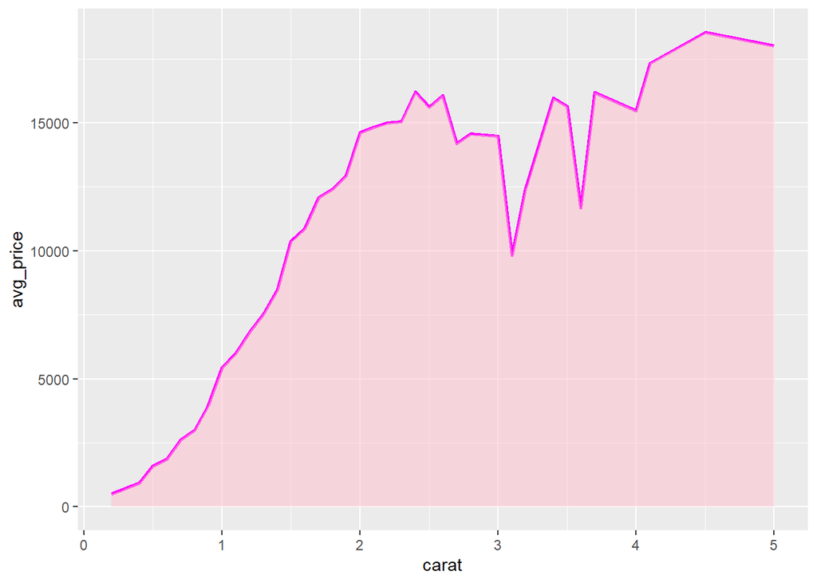

```r
ggplot(data = avgPriceByCarat, aes(x = carat,
                                   y = avg_price)) +
  geom_line(mapping = aes(x = carat,
                          y = avg_price),
            color = "magenta",
            linewidth = 1) +
  geom_area(fill = "pink",
            alpha = 0.5)
```

INTERPRETATION: This plot shows that the higher the carat, the higher the average price is, but there is a significant number of data that shows in between 3 and 4 carat, prices drop down almost the same to how 1-2 carats were priced.

Continuous vs. Discrete - We use boxplot to visualize the covariation between continuous and discrete variables.

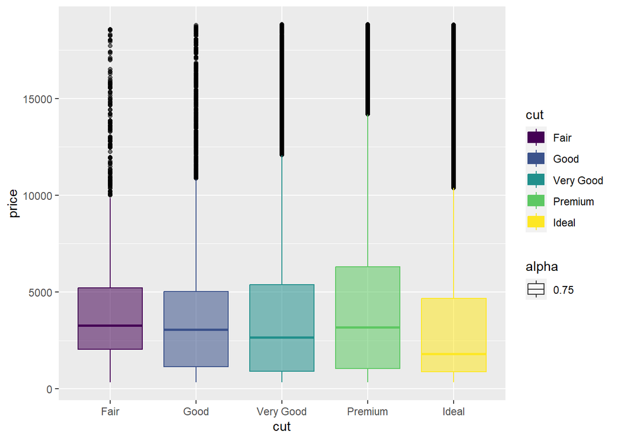

```r
ggplot(data = diamonds,
       aes(x = cut,
           y = price,
           fill = cut,
           color = cut,
           alpha = 0.75)) +
  geom_boxplot(mapping = aes(x = cut,
                             y = price),
               outlier.color = "black")
```

# **Lecture 3**

Exercise: Filter diamonds to those with ideal cut and at least 3 carats. How many such diamonds are there?

```r
filter(diamonds, cut %in% c("Ideal") & carat >= 3)
```

```
## # A tibble: 4 × 10
##   carat cut   color clarity depth table price     x     y     z
##   <dbl> <ord> <ord> <ord>   <dbl> <dbl> <int> <dbl> <dbl> <dbl>
## 1  3.22 Ideal I     I1       62.6    55 12545  9.49  9.42  5.92
## 2  3.5  Ideal H     I1       62.8    57 12587  9.65  9.59  6.03
## 3  3.01 Ideal J     SI2      61.7    58 16037  9.25  9.2   5.69
## 4  3.01 Ideal J     I1       65.4    60 16538  8.99  8.93  5.86
```

ANSWER: There are four diamonds that are in Ideal cut and has a carat greater than or equal to 3.

Exercise: Select all columns except x, y, z.

```r
select(diamonds, -x, -y, -z)
```

```
## # A tibble: 53,940 × 7
##    carat cut       color clarity depth table price
##    <dbl> <ord>     <ord> <ord>   <dbl> <dbl> <int>
##  1  0.23 Ideal     E     SI2      61.5    55   326
##  2  0.21 Premium   E     SI1      59.8    61   326
##  3  0.23 Good      E     VS1      56.9    65   327
##  4  0.29 Premium   I     VS2      62.4    58   334
##  5  0.31 Good      J     SI2      63.3    58   335
##  6  0.24 Very Good J     VVS2     62.8    57   336
##  7  0.24 Very Good I     VVS1     62.3    57   336
##  8  0.26 Very Good H     SI1      61.9    55   337
##  9  0.22 Fair      E     VS2      65.1    61   337
## 10  0.23 Very Good H     VS1      59.4    61   338
## # ℹ 53,930 more rows
```

```r
arrange(diamonds, desc(depth))
```

```
## # A tibble: 53,940 × 10
##    carat cut   color clarity depth table price     x     y     z
##    <dbl> <ord> <ord> <ord>   <dbl> <dbl> <int> <dbl> <dbl> <dbl>
##  1  0.5  Fair  E     VS2      79      73  2579  5.21  5.18  4.09
##  2  0.5  Fair  E     VS2      79      73  2579  5.21  5.18  4.09
##  3  1.03 Fair  E     I1       78.2    54  1262  5.72  5.59  4.42
##  4  0.99 Fair  J     I1       73.6    60  1789  6.01  5.8   4.35
##  5  0.9  Fair  G     SI1      72.9    54  2691  5.74  5.67  4.16
##  6  0.96 Fair  G     SI2      72.2    56  2438  6.01  5.81  4.28
##  7  1.02 Fair  H     VS1      71.8    56  4455  6.04  5.97  4.31
##  8  0.99 Fair  H     VS2      71.6    57  3593  5.94  5.8   4.2
##  9  0.7  Fair  D     SI2      71.6    55  1696  5.47  5.28  3.85
## 10  1.5  Fair  I     I1       71.3    58  4368  6.85  6.81  4.87
## # ℹ 53,930 more rows
```

Exercise: Add a variable called good_color that is TRUE if the color is D, E, F, G and FALSE otherwise.

```r
mutate(diamonds, good_color =
         if_else(
           condition = color %in% c("D", "E", "F", "G"),
           true = TRUE,
           false = FALSE))
```

```
## # A tibble: 53,940 × 11
##    carat cut       color clarity depth table price     x     y     z good_color
##    <dbl> <ord>     <ord> <ord>   <dbl> <dbl> <int> <dbl> <dbl> <dbl> <lgl>
##  1  0.23 Ideal     E     SI2      61.5    55   326  3.95  3.98  2.43 TRUE
##  2  0.21 Premium   E     SI1      59.8    61   326  3.89  3.84  2.31 TRUE
##  3  0.23 Good      E     VS1      56.9    65   327  4.05  4.07  2.31 TRUE
##  4  0.29 Premium   I     VS2      62.4    58   334  4.2   4.23  2.63 FALSE
##  5  0.31 Good      J     SI2      63.3    58   335  4.34  4.35  2.75 FALSE
##  6  0.24 Very Good J     VVS2     62.8    57   336  3.94  3.96  2.48 FALSE
##  7  0.24 Very Good I     VVS1     62.3    57   336  3.95  3.98  2.47 FALSE
##  8  0.26 Very Good H     SI1      61.9    55   337  4.07  4.11  2.53 FALSE
##  9  0.22 Fair      E     VS2      65.1    61   337  3.87  3.78  2.49 TRUE
## 10  0.23 Very Good H     VS1      59.4    61   338  4     4.05  2.39 FALSE
## # ℹ 53,930 more rows
```

Exercise: Use summarise to determine if there are any diamonds of at least one carat that cost less that $1000.

```r
summarise(diamonds, cheapDiamonds = any(price < 1000 & carat >= 1))
```

```
## # A tibble: 1 × 1
##   cheapDiamonds
##   <lgl>
## 1 FALSE
```

ANSWER: False (None)

Exercise: Compute the mean price for diamonds of volume at least one carat

```r
diamonds %>%
  filter(carat >= 1) %>%
  mutate(meanPrice = mean(price)) #%>%
```

```
## # A tibble: 19,060 × 11
##    carat cut       color clarity depth table price     x     y     z meanPrice
##    <dbl> <ord>     <ord> <ord>   <dbl> <dbl> <int> <dbl> <dbl> <dbl>     <dbl>
##  1  1.17 Very Good J     I1       60.2    61  2774  6.83  6.9   4.13     8142.
##  2  1.01 Premium   F     I1       61.8    60  2781  6.39  6.36  3.94     8142.
##  3  1.01 Fair      E     I1       64.5    58  2788  6.29  6.21  4.03     8142.
##  4  1.01 Premium   H     SI2      62.7    59  2788  6.31  6.22  3.93     8142.
##  5  1.05 Very Good J     SI2      63.2    56  2789  6.49  6.45  4.09     8142.
##  6  1.05 Fair      J     SI2      65.8    59  2789  6.41  6.27  4.18     8142.
##  7  1    Premium   I     SI2      58.2    60  2795  6.61  6.55  3.83     8142.
##  8  1.01 Fair      E     SI2      67.4    60  2797  6.19  6.05  4.13     8142.
##  9  1.04 Premium   G     I1       62.2    58  2801  6.46  6.41  4        8142.
## 10  1    Premium   J     SI2      62.3    58  2801  6.45  6.34  3.98     8142.
## # ℹ 19,050 more rows
```

```r
  #ggplot() +
  #geom_histogram(aes(x = meanPrice))
```

Exercise: Reproduce the output of count(diamonds, cut) via group_by() and summarise()

```r
count(diamonds, cut)
```

```
## # A tibble: 5 × 2
##   cut           n
##   <ord>     <int>
## 1 Fair       1610
## 2 Good       4906
## 3 Very Good 12082
## 4 Premium   13791
## 5 Ideal     21551
```

ANSWER:

```r
diamonds %>%
  group_by(cut) %>%
  summarise(n = n())
```

```
## # A tibble: 5 × 2
##   cut           n
##   <ord>     <int>
## 1 Fair       1610
## 2 Good       4906
## 3 Very Good 12082
## 4 Premium   13791
## 5 Ideal     21551
```

# **Lecture 4**

heights2 = read_csv(file = “heights2.csv”)

```r
table1
```

```
## # A tibble: 6 × 4
##   country      year  cases population
##   <chr>       <dbl>  <dbl>      <dbl>
## 1 Afghanistan  1999    745   19987071
## 2 Afghanistan  2000   2666   20595360
## 3 Brazil       1999  37737  172006362
## 4 Brazil       2000  80488  174504898
## 5 China        1999 212258 1272915272
## 6 China        2000 213766 1280428583
```

```r
table2
```

```
## # A tibble: 12 × 4
##    country      year type            count
##    <chr>       <dbl> <chr>           <dbl>
##  1 Afghanistan  1999 cases             745
##  2 Afghanistan  1999 population   19987071
##  3 Afghanistan  2000 cases            2666
##  4 Afghanistan  2000 population   20595360
##  5 Brazil       1999 cases           37737
##  6 Brazil       1999 population  172006362
##  7 Brazil       2000 cases           80488
##  8 Brazil       2000 population  174504898
##  9 China        1999 cases          212258
## 10 China        1999 population 1272915272
## 11 China        2000 cases          213766
## 12 China        2000 population 1280428583
```

```r
table3
```

```
## # A tibble: 6 × 3
##   country      year rate
##   <chr>       <dbl> <chr>
## 1 Afghanistan  1999 745/19987071
## 2 Afghanistan  2000 2666/20595360
## 3 Brazil       1999 37737/172006362
## 4 Brazil       2000 80488/174504898
## 5 China        1999 212258/1272915272
## 6 China        2000 213766/1280428583
```

ANSWER: table1 utilized columns to express variables/observations per country and year, table2 utilized rows in separating the observed variable, which is count on the last column, while table 3 used ration of case/population to simplify the presentation to three columns, yet still separated by year.

Exercise: Use pivot_longer() to tidy table4b in a similar fashion. What is the difference between the code used to tidy table4a and table4b?

```r
table4b
```

```
## # A tibble: 3 × 3
##   country         `1999`     `2000`
##   <chr>            <dbl>      <dbl>
## 1 Afghanistan   19987071   20595360
## 2 Brazil       172006362  174504898
## 3 China       1272915272 1280428583
```

ANSWER: The table4a tackles cases, while table4b tackles population.

```r
table4b %>%
  pivot_longer(cols = c(`1999`, `2000`), names_to = "year", values_to = "population")
```

```
## # A tibble: 6 × 3
##   country     year  population
##   <chr>       <chr>      <dbl>
## 1 Afghanistan 1999    19987071
## 2 Afghanistan 2000    20595360
## 3 Brazil      1999   172006362
## 4 Brazil      2000   174504898
## 5 China       1999  1272915272
## 6 China       2000  1280428583
```

Exercises:

```r
preg <- tribble(
  ~pregnant, ~male, ~female,
  "yes", NA, 10,
  "no", 20, 12
)
preg
```

```
## # A tibble: 2 × 3
##   pregnant  male female
##   <chr>    <dbl>  <dbl>
## 1 yes         NA     10
## 2 no          20     12
```

```r
preg %>%
  pivot_longer(cols = c(male, female), names_to = "gender", values_to = "Answer")
```

```
## # A tibble: 4 × 3
##   pregnant gender Answer
##   <chr>    <chr>   <dbl>
## 1 yes      male       NA
## 2 yes      female     10
## 3 no       male       20
## 4 no       female     12
```